# week4_homework

Shawn Wang

2026-02-10

# Tasks

Homework:

1. Read in Unabomber
2. Output structure - what form is it coming in? str?
3. Run cleaning genie - import cleaned version as a corpus
4. Table of lexical characteristics pre/post cleaning - number of types/tokens etc.
5. Lexical dispersion plot - pick 5 words
6. Word cloud
7. Print DFM - top 20 words

## Read in Unabomber

Here I am reading in the text files:

```r
#load in text as a single character vector
unabomb_raw <- paste(readLines('https://raw.githubusercontent.com/Reilly-ConceptsCognitionLab/reillylab_publicdata/main/unabomber_manifesto.txt'))
```

## Output structure

```r
str(unabomb_raw)
```

```
##  chr [1:3321] "INDUSTRIAL SOCIETY AND ITS FUTURE" "" "Introduction" "" ...
```

The Unabomber Manifesto is being imported as a character vector.

## Run cleaning genie

This cleaning genie will clean for punctuation and special characters, expand contractions, remove stopwords, lemmatize, etc. to return a tidy data frame where each row is a word. However, for conversion into a corpus, we will need to smash all of those rows of words back into a single cell. We then turn that corpus into tokens and then a document feature matrix.

```r
#run cleaning genie
unabomb_clean_df <- shawn_Cleaning_Genie(unabomb_raw) %>% #clean and tidy the raw text
  summarize(author = "TK",
            doc_text = paste(string, collapse = " ")) #turn back into a corpus-ready form


#this cleaned df is going to be one row with column author and another column doc_text, which you feed into corpus()
unabomb_corpus <- corpus(unabomb_clean_df,
                         doc_id_field = "author",
                         text_field = "doc_text")


#convert the corpus into tokens
tokens_unabomb <- tokens(unabomb_corpus)

#turn the tokens into a document feature matrix
dfm_unabomb <- dfm(tokens_unabomb)

names(unabomb_corpus) <- "Unabomber Manifesto"
```

## Some off-the-shelf statistics

Here are some lexical indices from the unabomber manifesto from the quanteda package:

```r
#lexical diversity
print(textstat_lexdiv(dfm_unabomb, measure = c("TTR", "C", "R", "CTTR", "U", "S", "K", "I", "D", "Vm", "Maas"), log.base = 10))
```

```
##   document       TTR         C        R    CTTR       U         S        K
## 1    text1 0.1813011 0.8231954 22.67931 16.0367 23.7237 0.8643001 26.51451
##          I          D         Vm      Maas     lgV0    lgeV0
## 1 12.15713 0.00265162 0.04860938 0.2053094 6.081567 14.00333
```

## Table of lexical characteristcs pre/post

```r
summary(unabomb_corpus)
```

| Text | Types | Tokens | Sentences | author |
| --- | --- | --- | --- | --- |
| Unabomber Manifesto | 2837 | 15648 | 1 | TK |

```r
#this unabomb_raw_df is just the raw data turned into a corpus for comparison purposes but not used in further analysis
unabomb_raw_df <- data.frame(
  author = "TK",
  doc_text = unabomb_raw
) %>%
  summarize(author = unique(author),
            doc_text = paste(doc_text, collapse = " "))
unabomb_raw_corpus <- corpus(unabomb_raw_df, doc_id_field = "author", text_field = "doc_text")
summary(unabomb_raw_corpus)
```

| Text | Types | Tokens | Sentences | author |
| --- | --- | --- | --- | --- |
| text1 | 4849 | 38997 | 1792 | TK |

There are 2837 unique words and 15648 words total in the cleaned manifesto, resulting in a TTR of 0.18. There are 4849 unique words and 38997 words total in the uncleaned manifesto, resulting in a TTR of 0.12.

## Lexical Dispersion Plot

We can generate a lexical dispersion plot to display the prevalence of words that we are interested in:

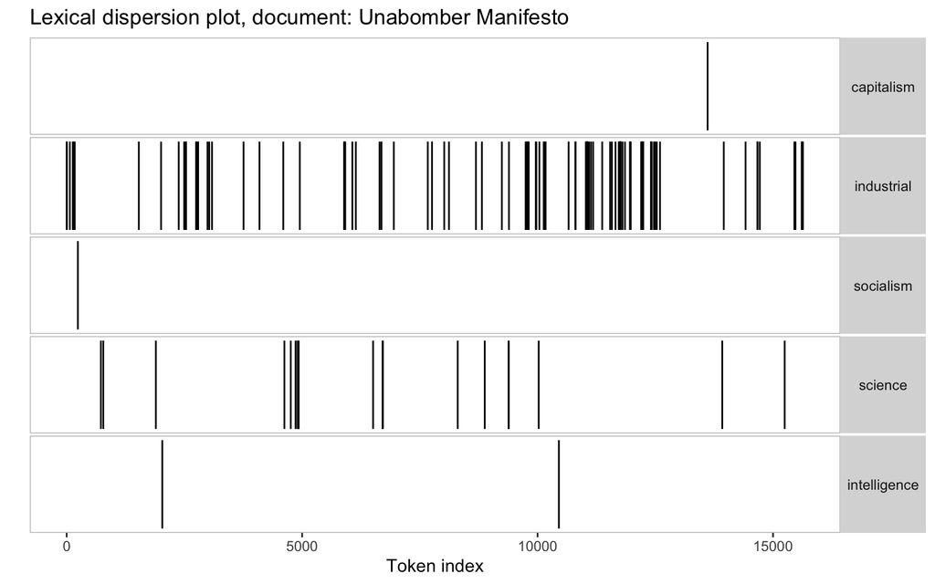

```r
#kwic is keywords in context, and searches for the words that we specify for it under "pattern"
#textplot_xray plots the dispersion
textplot_xray(
    kwic(tokens(unabomb_corpus), pattern = "capitalism"),
    kwic(tokens(unabomb_corpus), pattern = "industrial"),
    kwic(tokens(unabomb_corpus), pattern = "socialism"),
    kwic(tokens(unabomb_corpus), pattern = "science"),
    kwic(tokens(unabomb_corpus), pattern = "intelligence"),
    scale = "absolute"
)
```

## Word Cloud

We can also generate a wordcloud straight from the document feature matrix object using quanteda:

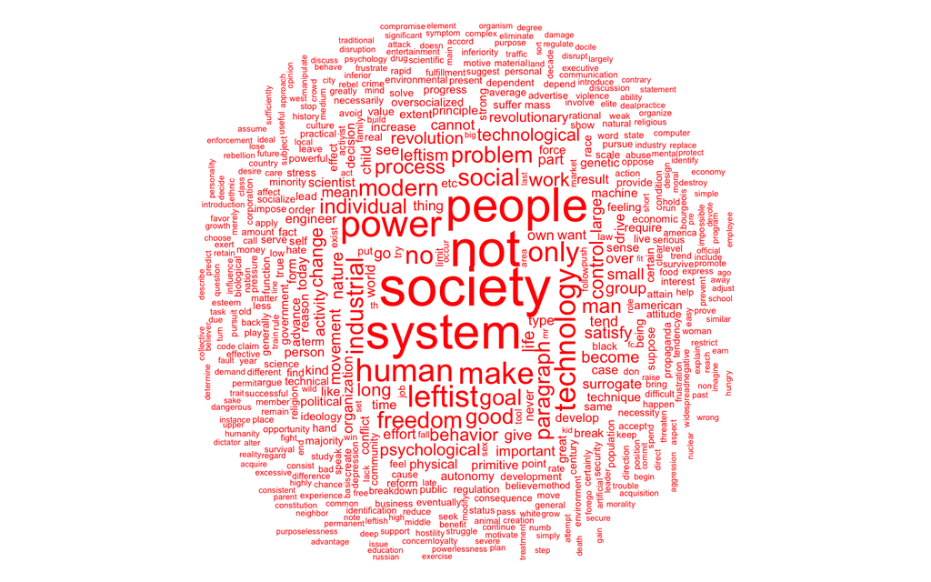

```r
quanteda.textplots::textplot_wordcloud(dfm_unabomb, random_order = FALSE, rotation = .25, color = "red")
```

## Document Feature Matrix

Finally, we can show the top 20 most common words in our cleaned dataset by feeding the document feature matrix object into the topfeatures() function while specifying the number of words we want:

```r
#print top 20 words
topfeatures(dfm_unabomb, 20)
```

```
##    society        not     system     people      power      human       make
##        271        247        236        226        170        141        134
##    leftist technology       only         no     social industrial     modern
##        132        127        118        104         98         97         94
##    freedom    problem       goal       good  paragraph individual
##         92         89         87         83         83         79
```